# Intro to DS - Linear Model part I

# HW assignment

## Linear model - Quantitative Regressors

### Question 1: Import & Subset Data

**Import the data, call it `bikeorig.`**  
The `Date` variable is probably imported as factor level variable. In any case, let us remove `Date`, `Casual.Users`, and `Registered.Users` in the dataset and save it as a new datafame, call it `bike`. How many variables are in `bike`? How many of them are imported as `int`? Feel free to rename longer variable names into shorter ones for convenience.

After removing the variables Date, Casual Users and Registered Users, there are a total of 11 variables. None of the variables are reported as integers. All of the variables are numeric.

```r
bikeorig<-read_csv("~/Documents/My6101Work/bikedata.csv")
#View(bikeorig)

bike<-subset(bikeorig, select= -c(1,12,13))
#View(bike)

sapply(bike, class)
```

### Question 2: Subset by Hour

**Select only the subset with `Hour` equal 16 only. Call it `bike16`**  
These are the afternoon rush hour data. How many observations are there?

After filtering the data to only contain data associated when Hour equals 16, there is a total of 730 observations.

```r
bike16<-filter(bike, Hour == 16)

count(bike16)
```

### Question 3: Factor Variables

**Before building any models, we should make sure the variables are set up properly.**  
(This problem is solved for you. Codes are given below.)  
Which ones should be recorded as categorical? Convert them now before we proceed to the model building.

Note: After converting, the correlation function `cor()` will not work with categorical/factor variables. I would keep the original `bike16` dataframe as numeric, and use that to find the correlation matrix. Although technically correlation between categorical and numeric variables are not well defined in general, we can still get some useful information if the categorical variable is at least at ordinal level. See future discussion on using “Pearson” vs “Spearman” methods for correlation tests.

While the `cor()` function does not accept categorical variables (and therefore we cannot use it for `corrplot()`), the `lattice::pairs()` function does not complain about categorical columns. We can still use it to get a visual distribution of data values from it.

```r
bike_final = bike16
bike_final$Season = factor(bike16$Season)
bike_final$Holiday = factor(bike16$Holiday)
bike_final$`Day of the Week` = factor(bike16$`Day of the Week`)
bike_final$`Working Day` = factor(bike16$`Working Day`)
bike_final$`Weather Type` = factor(bike16$`Weather Type`)
str(bike_final)
```

We decided to convert these variables into categorical (factor):  
`Season`, `Holiday`, `Day`, `Workday`, and `Weather`. Notice that the dataframe `bike16` still has all variables numerical, while the df `bike_final` include categorical columns that we just converted.

### Question 4: Pairs Plot

**Make a `pairs()` plot with all the variables (quantitative and qualitative).**

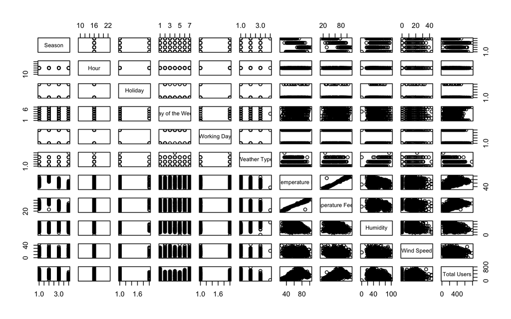

```r
pairs(bike_final)
```

### Question 5: Corrploty/Cor-matrix

**Make a `corrplot()` with only the numerical variables.**  
You can either subset the df with only numerical variables first, then create the create the cor-matrix to plot. Or you can create the cor-matrix from `bike16`, then select select out the portion of the matrix that you want. Use options that shows well the relationships between different variables.

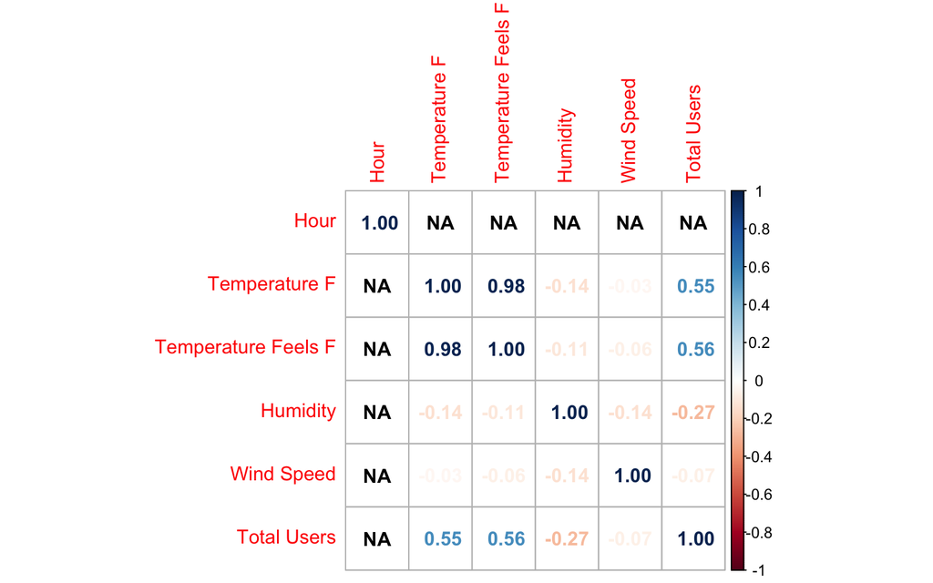

```r
sapply(bike_final, class)

#View(bike_final)

bike_final_numvar<-subset(bike_final, select = -c(1,3,4,5,6))
#View(bike_final_numvar)

M<-cor(bike_final_numvar)

corrplot(M, is.corr = TRUE, method = 'number', na.label='NA')
```

### Question 6: Linear Model 1

**By using numerical variables only, build a linear model with 1 independent variable to predict the `Total Users`.**  
Choose the variable with the strongest correlation coefficient. Make some short comments on the coefficient values, their p-values, and the multiple R-squared value.

The results of the linear model indicate that there is a positive association between Total Users and Temperature Feels F. This indicates that as Temperature Feels F increases, Total Users also increases. For every one unit increase in Temperature Feels F corresponds with a 4.024 increase in Total Users. Additionally the coefficient is statistically significant at the 5% significance level.

The intercept coefficient indicates that when Temperature Feels F equals 0, there is 44.530 Total Users. The intercept coefficient is statistically significant at the 5% significance level.

The multiple R-squared is 0.309. This indicates that the model does not fit the data very well. In other words, only 30.9% of the variation in Total Users variable can be explained by the Temperature Feels F variable.

```r
model1 <- lm(`Total Users`~`Temperature Feels F`, data=bike_final_numvar)
summary(model1)
```

```
##
## Call:
## lm(formula = `Total Users` ~ `Temperature Feels F`, data = bike_final_numvar)
##
## Residuals:
##    Min     1Q Median     3Q    Max
## -308.7  -88.9   -5.6   78.7  428.6
##
## Coefficients:
##                       Estimate Std. Error t value Pr(>|t|)
## (Intercept)             44.530     15.510    2.87   0.0042 **
## `Temperature Feels F`    4.024      0.223   18.05   <2e-16 ***
## ---
## Signif. codes:  0 '***' 0.001 '**' 0.01 '*' 0.05 '.' 0.1 ' ' 1
##
## Residual standard error: 124 on 728 degrees of freedom
## Multiple R-squared:  0.309,  Adjusted R-squared:  0.308
## F-statistic:  326 on 1 and 728 DF,  p-value: <2e-16
```

### Question 7: Linear Model 2

**Next, add a second variable to the model.**  
Choose the variable with the next strongest correlation, but avoid using obviously collinear variables. When you have the model, check the VIF values. If the VIF is higher than 5, discard this model, and try the variable with the next strongest correlation until you find one that works (ideally with vif’s <5, or if you have to, allow vif up to 10). Again, comment on the coefficient values, their p-values, and the multiple R-squared value.

The results of the linear model indicate that there is a positive association between Total Users and Temperature Feels F. This indicates that as Temperature Feels F increases, Total Users also increases. For every one unit increase in Temperature Feels F corresponds with a 3.859 increase in Total Users. Additionally the coefficient is statistically significant at the 5% significance level. The results of the linear model also indicate that there is a negative association between Total Users and Humidity. This indicates that as Humidity increases, Total Users decreases For every one unit increase in Humidity corresponds with a -1.678 decrease in Total Users. Additionally the coefficient is statistically significant at the 5% significance level

The intercept coefficient indicates that when Temperature Feels F and Humidity equal 0, there is 138.712 Total Users. The intercept coefficient is statistically significant at the 5% significance level.

The multiple R-squared is 0.354. This indicates that the model does not fit the data very well. In other words, only 35.4% of the variation in Total Users variable can be explained by the Temperature Feels F and Humidity variables.

The VIF value for Temperature Feel F is 1.01. The VIF value for Humidity is 1.01. This indicates that there is low correlation among the independent variables.

```r
model2 <- lm(`Total Users`~`Temperature Feels F`+ Humidity, data=bike_final_numvar)
summary(model2)
```

```
##
## Call:
## lm(formula = `Total Users` ~ `Temperature Feels F` + Humidity,
##     data = bike_final_numvar)
##
## Residuals:
##    Min     1Q Median     3Q    Max
## -324.5  -83.7   -8.9   73.7  407.5
##
## Coefficients:
##                       Estimate Std. Error t value Pr(>|t|)
## (Intercept)            138.712     20.001    6.94  9.0e-12 ***
## `Temperature Feels F`    3.859      0.217   17.78  < 2e-16 ***
## Humidity                -1.678      0.236   -7.12  2.6e-12 ***
## ---
## Signif. codes:  0 '***' 0.001 '**' 0.01 '*' 0.05 '.' 0.1 ' ' 1
##
## Residual standard error: 120 on 727 degrees of freedom
## Multiple R-squared:  0.354,  Adjusted R-squared:  0.352
## F-statistic:  199 on 2 and 727 DF,  p-value: <2e-16
```

```r
vif(model2)
```

```
## `Temperature Feels F`              Humidity
##                  1.01                  1.01
```

### Question 8: Linear Model 3

**We will try one more time as in the previous question, to add a third variable in our model.**

The results of the linear model indicate that there is a positive association between Total Users and Temperature Feels F. This indicates that as Temperature Feels F increases, Total Users also increases. For every one unit increase in Temperature Feels F corresponds with a 3.823 increase in Total Users. Additionally the coefficient is statistically significant at the 5% significance level. The results of the linear model also indicate that there is a negative association between Total Users and Humidity. This indicates that as Humidity increases, Total Users decreases For every one unit increase in Humidity corresponds with a -1.750 decrease in Total Users. Additionally the coefficient is statistically significant at the 5% significance level. Finally, the results of the linear model also indicate that there is a negative association between Total Users and Wind Speed. This indicates that as Wind Speed increases, Total Users decreases. For every one unit increase in Wind Speed corresponds with a -1.137 decrease in Total Users. Additionally the coefficient is statistically significant at the 5% significance level.

The intercept coefficient indicates that when Temperature Feels F, Humidity, and Wind Speed equal 0, there is 162.710 Total Users. The intercept coefficient is statistically significant at the 5% significance level.

The VIF value for Temperature Feel F is 1.02. The VIF value for Humidity is 1.03. The VIF value for Wind Spee is 1.03. This indicates that there is low correlation among the independent variables.

```r
model3 <- lm(`Total Users`~`Temperature Feels F`+Humidity+`Wind Speed`, data=bike_final_numvar)
summary(model3)
```

```
##
## Call:
## lm(formula = `Total Users` ~ `Temperature Feels F` + Humidity +
##     `Wind Speed`, data = bike_final_numvar)
##
## Residuals:
##    Min     1Q Median     3Q    Max
## -327.3  -82.7   -9.8   75.7  405.9
##
## Coefficients:
##                       Estimate Std. Error t value Pr(>|t|)
## (Intercept)            162.710     23.006    7.07  3.6e-12 ***
## `Temperature Feels F`    3.823      0.217   17.61  < 2e-16 ***
## Humidity                -1.750      0.237   -7.37  4.8e-13 ***
## `Wind Speed`            -1.137      0.543   -2.10    0.036 *
## ---
## Signif. codes:  0 '***' 0.001 '**' 0.01 '*' 0.05 '.' 0.1 ' ' 1
##
## Residual standard error: 119 on 726 degrees of freedom
## Multiple R-squared:  0.358,  Adjusted R-squared:  0.355
## F-statistic:  135 on 3 and 726 DF,  p-value: <2e-16
```

```r
vif(model3)
```

```
## `Temperature Feels F`              Humidity          `Wind Speed`
##                  1.02                  1.03                  1.03
```

### Question 9: CI for Coefficients

**For the 3-variable model you found, find the confidence intervals of the coefficients.**

```r
xkabledply(confint(model3, level = 0.95), title = "Confidence Intervals for the Coefficents of Model 3")
```

Confidence Intervals for the Coefficents of Model 3

|  | 2.5 % | 97.5 % |
| --- | --- | --- |
| (Intercept) | 117.54 | 207.8765 |
| `Temperature Feels F` | 3.40 | 4.2498 |
| Humidity | -2.22 | -1.2833 |
| `Wind Speed` | -2.20 | -0.0718 |

### Question 10: ANOVA Tests for Models

**Use ANOVA to compare the three different models you found.**  
You have found three different models. Use ANOVA test to compare their residuals. What conclusion can you draw?

```r
aov1<-aov(lm(`Total Users`~`Temperature Feels F`, data=bike_final_numvar))
xkabledply(summary(aov1), title = "ANOVA Test for Model 1")
```

ANOVA Test for Model 1

|  | Df | Sum Sq | Mean Sq | F value | Pr(>F) |
| --- | --- | --- | --- | --- | --- |
| `Temperature Feels F` | 1 | 4981782 | 4981782 | 326 | 0 |
| Residuals | 728 | 11133872 | 15294 | NA | NA |

```r
aov2<-aov(lm(`Total Users`~`Temperature Feels F`+ Humidity, data=bike_final_numvar))
xkabledply(summary(aov2), title ="ANOVA Test for Model 2")
```

ANOVA Test for Model 2

|  | Df | Sum Sq | Mean Sq | F value | Pr(>F) |
| --- | --- | --- | --- | --- | --- |
| `Temperature Feels F` | 1 | 4981782 | 4981782 | 348.0 | 0 |
| Humidity | 1 | 726209 | 726209 | 50.7 | 0 |
| Residuals | 727 | 10407664 | 14316 | NA | NA |

```r
aov3<-aov(lm(`Total Users`~`Temperature Feels F`+ Humidity + `Wind Speed`, data=bike_final_numvar))
xkabledply(summary(aov3), title = "ANOVA Test for Model 3")
```

ANOVA Test for Model 3

|  | Df | Sum Sq | Mean Sq | F value | Pr(>F) |
| --- | --- | --- | --- | --- | --- |
| `Temperature Feels F` | 1 | 4981782 | 4981782 | 349.61 | 0.0000 |
| Humidity | 1 | 726209 | 726209 | 50.96 | 0.0000 |
| `Wind Speed` | 1 | 62580 | 62580 | 4.39 | 0.0365 |
| Residuals | 726 | 10345083 | 14249 | NA | NA |